# Trabajo Final

Trabajo Final Minor Solano Gutiérrez 3/12/2020

Proyecto final

Curso: Herramientas prácticas para investigación reproducible

Estudiante: Minor Solano Gutiérrez

II-2020

Link al repositorio GitHub https://github.com/Minorsg/Trabajo_final.git

# Tema

Influencia de la complejidad estructural de la comunidad vegetal del entorno en la composición de especies de escamas armadas (Hemiptera: Diaspididae) y sus parasitoides, en palmas ornamentales en ambientes urbanos en Costa Rica

# Pregunta

¿Cuál impacto tiene la complejidad estructural de la comunidad vegetal del entorno en la abundancia y diversidad de avispas parasitoides de escamas armadas (Hemiptera: Diaspididae) en palmas ornamentales en ambientes urbanos?

# Hipótesis

La diversidad de especies de escamas Diaspididae y sus parasitoides Hymenoptera en palmas ornamentales variará según la complejidad estructural de la comunidad vegetal entorno, donde, en hábitats más complejos (p. e. parques) habrá una mayor diversidad (H’) de especies, tanto de escamas, como de parasitoides, respecto a un hábitat más simple (p. e. bordes de calle o parqueos). Pero no una mayor uniformidad de especies (J’) (i.e. la proporción de la diversidad observada en cada hábitat, respecto a máxima diversidad posible, i.e. riqueza total), debido a las especies de especialistas de cada hábitat. Por lo que, se espera menos diversidad, pero con abundancias relativas más estables por la proporción de especies de especialistas en hábitats simples, respecto a mayor diversidad, pero con abundancias relativas menores y más heterogéneas en hábitat complejos. Esto podría explicar las razones por las cuáles zonas con una baja complejidad vegetal del entorno son más propensas a experimentar grandes incrementos en las poblaciones de escamas y proponer métodos de manejo más sostenibles de poblaciones de estos insectos basados en aumentar la complejidad estructural de la comunidad vegetal del entorno.

El número de plantas (V) influencia la complejidad estructural de la comunidad vegetal del entorno (x), tanto el número de plantas como la complejidad estructural influye en la diversidad de escamas (HE) y esta en la abundancia (E) de estos insectos herbívoros. Las escamas son hospederos de los parasitoides y una mayor abundanacia (E) causan mayor abundancia de parasitoides (A) y una mayor diversidad de escamas (HE) y mayor diversidad de parasitoides (y).La abundacia influye sobre la proporción de especialistas (S) y este a su vez sobre la uniformidad de especies (J)

En este trabajo daremos énfasis a nuestra pregunta principalmente que busca responder si la complejidad estructural causa una mayor diversidad de parasitoides

## DAG

```r
#Crear DAG

library(ggdag) #cargar libreria ggdag
escamas <- dagify(x ~ V,
                  HE ~ V,
                  HE ~ x,
                  E ~ HE,
                  A ~ E,
                  y ~ HE,
                  S ~ E,
                  S ~ A,
                  J ~ S,
                  J ~ HE,
                  J ~ y,
                   A ~ y,


                  exposure = "x",
                  outcome = "y")
tidy_dagitty(escamas)
```

```
## # A DAG with 8 nodes and 12 edges
## #
## # Exposure: x
## # Outcome: y
## #
## # A tibble: 13 x 8
##    name      x     y direction to     xend  yend circular
##    <chr> <dbl> <dbl> <fct>     <chr> <dbl> <dbl> <lgl>
##  1 A      2.49  15.0 ->        S      3.21  15.3 FALSE
##  2 E      3.59  14.4 ->        A      2.49  15.0 FALSE
##  3 E      3.59  14.4 ->        S      3.21  15.3 FALSE
##  4 HE     5.07  14.9 ->        E      3.59  14.4 FALSE
##  5 HE     5.07  14.9 ->        J      4.44  16.0 FALSE
##  6 HE     5.07  14.9 ->        y      3.71  15.8 FALSE
##  7 S      3.21  15.3 ->        J      4.44  16.0 FALSE
##  8 V      6.59  14.9 ->        HE     5.07  14.9 FALSE
##  9 V      6.59  14.9 ->        x      6.30  14.1 FALSE
## 10 x      6.30  14.1 ->        HE     5.07  14.9 FALSE
## 11 y      3.71  15.8 ->        A      2.49  15.0 FALSE
## 12 y      3.71  15.8 ->        J      4.44  16.0 FALSE
## 13 J      4.44  16.0 <NA>      <NA>  NA     NA   FALSE
```

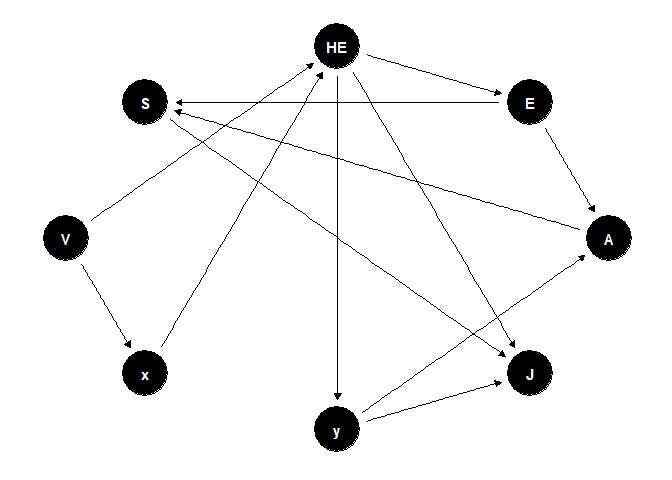

```r
ggdag(escamas, layout = "circle") + theme_dag()
```

```r
# enumerar covariables
library(dagitty) #cargar libreria dagitty

adjustmentSets(x = escamas, exposure = "x", outcome = "y", type="all", effect = "total")
```

```
## { V }
```

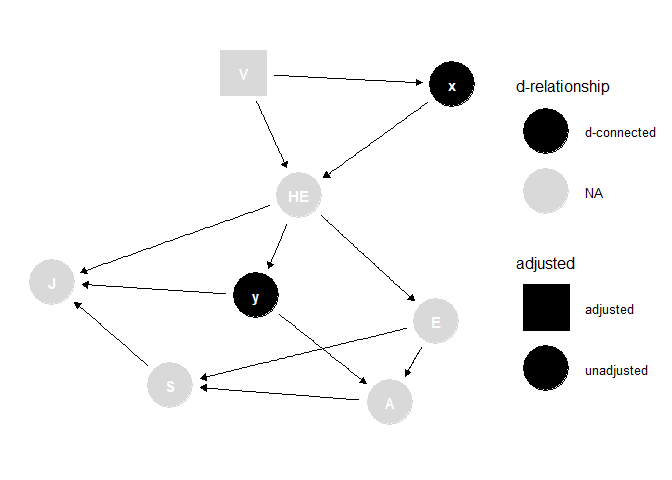

```r
# Vemos que existe una relacion entre x y y a traves del pipe HE


# Compactar
td_dag <- tidy_dagitty(escamas)


# Controlaremos por el fork V

# d relativos
d_node <- node_dseparated(td_dag, "x", "y", controlling_for = "V")

# grafico DAG compactado
ggplot(d_node, aes(
  x = x,
  y = y,
  xend = xend,
  yend = yend,
  shape = adjusted,
  col= d_relationship
)) +
  geom_dag_edges_link()+
  geom_dag_point() +
  geom_dag_text(col = "white") +
  theme_dag() +
  scale_adjusted() +
  expand_plot(expand_y = expansion(c(0.2, 0.2))) +
  scale_color_manual(values = c("Black", "White"),
                     name = "d-relationship",
                     na.value = "grey85"
  )
```

```r
# Implicaciones de independencia.

impliedConditionalIndependencies(x = escamas, type = "missing.edge")
```

```
## A _||_ HE | E, y
## A _||_ J | HE, S, y
## A _||_ J | E, S, y
## A _||_ V | HE
## A _||_ V | E, y
## A _||_ x | HE
## A _||_ x | E, y
## E _||_ J | HE, S, y
## E _||_ V | HE
## E _||_ x | HE
## E _||_ y | HE
## HE _||_ S | A, E
## HE _||_ S | E, y
## J _||_ V | HE
## J _||_ x | HE
## S _||_ V | HE
## S _||_ V | E, y
## S _||_ V | A, E
## S _||_ x | HE
## S _||_ x | E, y
## S _||_ x | A, E
## S _||_ y | A, E
## V _||_ y | HE
## x _||_ y | HE
```

```r
impliedConditionalIndependencies(x = escamas, type = "basis.set")
```

```
## A _||_ HE, V, x | E, y
## E _||_ V, x, y | HE
## J _||_ A, E, V, x | HE, S, y
## S _||_ HE, V, x, y | A, E
## y _||_ E, V, x | HE
```

# Datos

Los datos se tomarán en 24 sitios en 9 momentos distintos (frecuencia mensual), por lo que, los datos serán simulados partiendo de esta premisa

```r
#Simularemos los datos

#Primero generar un data frame con la información de sitios y momentos de muestreo

sitios1 <- rep("s", 216)
sitios2 <- rep(1:24, each = 1)
sitios3 <- rep(sitios2, 9)
sitio <- paste(sitios1, sitios3)

muestreos1 <- rep("m", 216)
muestreos2 <- rep(1:9, each = 24)
muestreo <- paste(muestreos1, muestreos2)

datos <- data.frame(muestreo, sitio)
str(datos)
```

```
## 'data.frame':    216 obs. of  2 variables:
##  $ muestreo: chr  "m 1" "m 1" "m 1" "m 1" ...
##  $ sitio   : chr  "s 1" "s 2" "s 3" "s 4" ...
```

```r
#Hay un espacio innecesario en los datos de muestreo

quitarespacio <- function(x, y, datos){
  datos
  searchString <- (x)
  replacementString <- (y)
  datos = gsub(searchString,replacementString,datos)
}
datos$muestreo <- quitarespacio("m 1", "m1", datos$muestreo)
datos$muestreo <- quitarespacio("m 2", "m2", datos$muestreo)
datos$muestreo <- quitarespacio("m 3", "m3", datos$muestreo)
datos$muestreo <- quitarespacio("m 4", "m4", datos$muestreo)
datos$muestreo <- quitarespacio("m 5", "m5", datos$muestreo)
datos$muestreo <- quitarespacio("m 6", "m6", datos$muestreo)
datos$muestreo <- quitarespacio("m 7", "m7", datos$muestreo)
datos$muestreo <- quitarespacio("m 8", "m8", datos$muestreo)
datos$muestreo <- quitarespacio("m 9", "m9", datos$muestreo)
```

## Simulación con las relaciones de dependencia específicadas

Los datos de V y x son conteos, por lo que son datos discretos y dado esto no simularemos datos siguiendo una distribución normal Importante aclarar que en los datos reales podría haber sobre dispersión, lo que es más posible por lo que se simulará con una distribución binomial negativa para x

Número de palmas (plantas hospederas del insecto fitófago) en el sitio de muestreo

```r
# V = número de palmas (plantas hospederas del insecto fitófago) en el sitio de muestreo
# En el caso de V, no pueden haber datos con cero palmas, porque haber palmas es un requisito, por lo que usaremos la función rtpois de la libreria extraDistr

library(extraDistr) #cargar libreria extraDistr
V <- rtpois(24, lambda = 4, a = 1, b = 6)
```

Complejidad estructural de la comunidad vegetal del entorno

Se utilizará se utilizará un índice de complejidad estructural (“SCI”, por sus siglas en inglés; [1,2]. Este es un índice tridimensional del hábitat en estudio el cual consiste de un área de 10 x 10 m alrededor de la planta en estudio.

Esto hace una cuadrícula tridimensional de 10 x 10 m (100 m2) por cinco estratos de vegetación (100 m2 x 5 estratos = 500 cuadrados en total). El número total de cuadrados con vegetación representará el SCI para ese paisaje (SCI máximo = 500). Un SCI < 125 = un paisaje simple y un SCI > 175 = un paisaje complejo.

```r
# x = complejidad estructural de la comunidad vegetal del entorno

x <- rnbinom(n = 24, mu = 40, size = 5)*V # x depende de V
```

Diversidad de escamas y parasitoides

Los muestreos se harán durante 9 momentos distintos, por lo que se simularán datos de diversidad para cada momento de muestreo

HE = diversidad de escamas, y = diversidad de parasitoides.

En este caso diversidad si se podría simular con una distribución normal, ya que si se tiene un conjunto de índices de diversidad replicados de diferentes sitios, el índice de diversidad podría considerarse como observaciones

```r
# HE = diversidad de escamas, en este caso diversidad si se podría simular con una distribución normal, ya que si se tiene un conjunto de índices de diversidad replicados de diferentes sitios, el índice de diversidad podría considerarse como observaciones

# Le damos mayor peso a su dependencia con V

HE.err1 <- rnorm(n = 24, mean = 0, sd = 0.5)
HE1 <- 0 + 0.06*V + 0.05*x + HE.err1 # E depende de V y de x

HE.err2 <- rnorm(n = 24, mean = 0, sd = 0.6)
HE2 <- 0 + 0.06*V + 0.05*x + HE.err2

HE.err3 <- rnorm(n = 24, mean = 0, sd = 0.4)
HE3 <- 0 + 0.06*V + 0.05*x + HE.err3

HE.err4 <- rnorm(n = 24, mean = 0, sd = 0.5)
HE4 <- 0 + 0.06*V + 0.05*x + HE.err4

HE.err5 <- rnorm(n = 24, mean = 0, sd = 0.3)
HE5 <- 0 + 0.06*V + 0.05*x + HE.err5

HE.err6 <- rnorm(n = 24, mean = 0, sd = 0.7)
HE6 <- 0 + 0.06*V + 0.05*x + HE.err6

HE.err7 <- rnorm(n = 24, mean = 0, sd = 0.5)
HE7 <- 0 + 0.06*V + 0.05*x + HE.err7

HE.err8 <- rnorm(n = 24, mean = 0, sd = 0.6)
HE8 <- 0 + 0.06*V + 0.05*x + HE.err8

HE.err9 <- rnorm(n = 24, mean = 0, sd = 0.4)
HE9 <- 0 + 0.06*V + 0.05*x + HE.err9

HE <- c(HE1, HE2, HE3, HE4, HE5, HE6, HE7, HE8, HE9)

datos$HE <- HE
head(datos)
```

```
##   muestreo sitio        HE
## 1       m1   s 1 10.205835
## 2       m1   s 2  4.298843
## 3       m1   s 3  3.056052
## 4       m1   s 4  9.177291
## 5       m1   s 5 12.183950
## 6       m1   s 6  4.099837
```

```r
# y = diversidad de parasitoides
y.err1 <- rnorm(n = 24, mean = 0, sd = 0.4)
y1 <- 0 + 0.75*HE1 + y.err1 # y depende de HE

y.err2 <- rnorm(n = 24, mean = 0, sd = 0.5)
y2 <- 0 + 0.75*HE1 + y.err2

y.err3 <- rnorm(n = 24, mean = 0, sd = 0.7)
y3 <- 0 + 0.75*HE1 + y.err3

y.err4 <- rnorm(n = 24, mean = 0, sd = 0.5)
y4 <- 0 + 0.75*HE1 + y.err4

y.err5 <- rnorm(n = 24, mean = 0, sd = 0.3)
y5 <- 0 + 0.75*HE1 + y.err5

y.err6 <- rnorm(n = 24, mean = 0, sd = 0.7)
y6 <- 0 + 0.75*HE1 + y.err6

y.err7 <- rnorm(n = 24, mean = 0, sd = 0.5)
y7 <- 0 + 0.75*HE1 + y.err7

y.err8 <- rnorm(n = 24, mean = 0, sd = 0.4)
y8 <- 0 + 0.75*HE1 + y.err8

y.err9 <- rnorm(n = 24, mean = 0, sd = 0.6)
y9 <- 0 + 0.75*HE1 + y.err9

y <- c(y1, y2, y3, y4, y5, y6, y7, y8, y9)

datos$y <- y
head(datos)
```

```
##   muestreo sitio        HE        y
## 1       m1   s 1 10.205835 8.052369
## 2       m1   s 2  4.298843 3.425149
## 3       m1   s 3  3.056052 2.530644
## 4       m1   s 4  9.177291 6.969360
## 5       m1   s 5 12.183950 9.218367
## 6       m1   s 6  4.099837 2.766790
```

```r
# Como se consideró en la simulación de diversidad, la complejidad de la comunidad vegetal del entorno y el número plantas hospederas del fitófago posible se mantenga en cada momento de muestreo
#Las incluímos al data frame
V <- rep(V, 9)
datos$V <- V
x <- rep(x, 9)
datos$x <- x

head(datos)
```

```
##   muestreo sitio        HE        y V   x
## 1       m1   s 1 10.205835 8.052369 5 190
## 2       m1   s 2  4.298843 3.425149 2  62
## 3       m1   s 3  3.056052 2.530644 2  48
## 4       m1   s 4  9.177291 6.969360 5 180
## 5       m1   s 5 12.183950 9.218367 4 240
## 6       m1   s 6  4.099837 2.766790 5  75
```

```r
str(datos)
```

```
## 'data.frame':    216 obs. of  6 variables:
##  $ muestreo: chr  "m1" "m1" "m1" "m1" ...
##  $ sitio   : chr  "s 1" "s 2" "s 3" "s 4" ...
##  $ HE      : num  10.21 4.3 3.06 9.18 12.18 ...
##  $ y       : num  8.05 3.43 2.53 6.97 9.22 ...
##  $ V       : num  5 2 2 5 4 5 4 5 3 2 ...
##  $ x       : num  190 62 48 180 240 75 148 120 210 34 ...
```

```r
summary(datos)
```

```
##    muestreo            sitio                 HE               y
##  Length:216         Length:216         Min.   : 0.212   Min.   : 0.674
##  Class :character   Class :character   1st Qu.: 3.664   1st Qu.: 2.869
##  Mode  :character   Mode  :character   Median : 6.560   Median : 5.138
##                                        Mean   : 7.545   Mean   : 5.839
##                                        3rd Qu.:10.123   3rd Qu.: 7.770
##                                        Max.   :24.947   Max.   :19.579
##        V               x
##  Min.   :2.000   Min.   : 34.0
##  1st Qu.:2.000   1st Qu.: 70.0
##  Median :4.000   Median :129.0
##  Mean   :3.583   Mean   :146.2
##  3rd Qu.:5.000   3rd Qu.:193.5
##  Max.   :5.000   Max.   :485.0
```

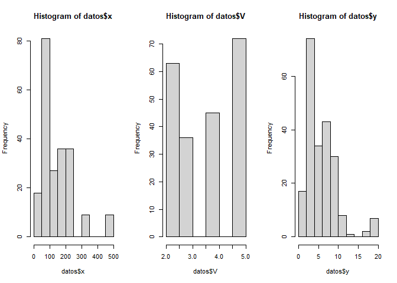

```r
#Importante recordar que según nuestro DAG, hay relacion entre x y y a traves del pipe HE y que deberiamos poder detectar si controlamos por V:

# Exploración de distribución con histográmas

par(mfrow = c(1, 3))
hist(datos$x)
hist(datos$V)
hist(datos$y)
```

```r
#Se observa un distribución no normal
```